# LAB GLMM

Author

A.Teixeira-Pinto & J. Harezlak

# Examples in the slides

Required libraries for different parts of the analysis.

```r
library(tidyverse)
library(geepack)
library(ggplot2)
library(lme4)
library(gtsummary)
```

## Read and prepare the data

**Dataset**: `bk.csv`

**Description**: After kidney transplant, patients are at risk of infection due to the immunosuppression therapy. BK virus poses an important risk in this populatio. The dataset bk.csv includes 2009 patients (variable `ID`) with 8435 observations. The variable `bk` that identifies the infection status of patients over time `time` – infected vs not infected. The observations within patients are likely correlated

**Other variables**:

Let’s load the data and create a summary table

```r
#Read the dataset BK from a shared dropbox folder
bk.Data <- read.csv("https://www.dropbox.com/scl/fi/l90jry0hbop1uu9s33hvw/bk.csv?rlkey=w2rfsu890i55hghgqhcn6sdy1&st=zog39nr6&dl=1")
#Descriptive table
tbl_summary(bk.Data)
```

| **Characteristic** | **N = 8,435**<sup>1</sup> |
| --- | --- |
| ID | 263,046 (249,317, 271,577) |
| bk | 174 (2.1%) |
| gendercode |  |
| F | 3,108 (37%) |
| M | 5,327 (63%) |
| donoragecat |  |
| <20 | 709 (8.4%) |
| >=70 | 126 (1.5%) |
| 20-29 | 1,044 (12%) |
| 30-39 | 1,014 (12%) |
| 40-49 | 1,991 (24%) |
| 50-59 | 2,235 (26%) |
| 60-69 | 1,316 (16%) |
| DonorSource |  |
| Deceased | 6,581 (78%) |
| Living | 1,854 (22%) |
| ischaemia | 9.0 (5.0, 13.0) |
| days_after_transplant | 526 (226, 924) |
| egfr | 58 (44, 73) |
| bkload | 0 (0, 0) |
| time | 1.44 (0.62, 2.53) |

<sup>1</sup> Median (Q1, Q3); n (%)

```r
#Number of of patient with 0, 1, 2, ... 5 BK events
bk.Data %>%
  group_by(ID) %>%
  summarize(bkevents = sum(bk)) %>%
  select(bkevents) %>%
  tbl_summary()
```

| **Characteristic** | **N = 2,009**<sup>1</sup> |
| --- | --- |
| bkevents |  |
| 0 | 1,870 (93%) |
| 1 | 117 (5.8%) |
| 2 | 13 (0.6%) |
| 3 | 6 (0.3%) |
| 4 | 2 (<0.1%) |
| 5 | 1 (<0.1%) |

<sup>1</sup> n (%)

## Logistic regression for BK status with GEE

Around slide 12 and forward

```r
#Fitting a logistic regression to BK status
#ignoring the correlation of the observations
logit.bk <- glm(bk ~ time,
                family=binomial,
                data=bk.Data)
summary(logit.bk)
```

```
Call:
glm(formula = bk ~ time, family = binomial, data = bk.Data)

Coefficients:
            Estimate Std. Error z value Pr(>|z|)
(Intercept) -3.19683    0.11083 -28.843  < 2e-16 ***
time        -0.46667    0.07536  -6.193 5.92e-10 ***
---
Signif. codes:  0 '***' 0.001 '**' 0.01 '*' 0.05 '.' 0.1 ' ' 1

(Dispersion parameter for binomial family taken to be 1)

    Null deviance: 1695.0  on 8434  degrees of freedom
Residual deviance: 1635.9  on 8433  degrees of freedom
AIC: 1639.9

Number of Fisher Scoring iterations: 8
```

```r
exp(logit.bk$coefficients)
```

```
(Intercept)        time
 0.04089169  0.62708681
```

```r
#Fitting a logistic regression to BK status
#using a GEE with independent working correlation matrix
gee.bk.ind <- geeglm(bk ~ time,
                family=binomial,
                id=ID,
                corst="independence",
                data=bk.Data)
summary(gee.bk.ind)
```

```
Call:
geeglm(formula = bk ~ time, family = binomial, data = bk.Data,
    id = ID, corstr = "independence")

 Coefficients:
            Estimate  Std.err   Wald Pr(>|W|)
(Intercept) -3.19683  0.12392 665.51  < 2e-16 ***
time        -0.46667  0.08178  32.56 1.16e-08 ***
---
Signif. codes:  0 '***' 0.001 '**' 0.01 '*' 0.05 '.' 0.1 ' ' 1

Correlation structure = independence
Estimated Scale Parameters:

            Estimate Std.err
(Intercept)   0.9786   1.047
Number of clusters:   2009  Maximum cluster size: 13
```

```r
exp(gee.bk.ind$coefficients)
```

```
(Intercept)        time
    0.04089     0.62709
```

```r
#Fitting a logistic regression to BK status
#using a GEE with exchangeable working correlation matrix
gee.bk.exch <- geeglm(bk~time,
                     family=binomial,
                     id=ID,
                     corst="exchangeable",
                     data=bk.Data)
summary(gee.bk.exch)
```

```
Call:
geeglm(formula = bk ~ time, family = binomial, data = bk.Data,
    id = ID, corstr = "exchangeable")

 Coefficients:
            Estimate Std.err  Wald Pr(>|W|)
(Intercept)  -3.0406  0.1256 585.9  < 2e-16 ***
time         -0.5692  0.0972  34.3  4.7e-09 ***
---
Signif. codes:  0 '***' 0.001 '**' 0.01 '*' 0.05 '.' 0.1 ' ' 1

Correlation structure = exchangeable
Estimated Scale Parameters:

            Estimate Std.err
(Intercept)     1.02    1.79
  Link = identity

Estimated Correlation Parameters:
      Estimate Std.err
alpha    0.144   0.273
Number of clusters:   2009  Maximum cluster size: 13
```

```r
exp(gee.bk.exch$coefficients)
```

```
(Intercept)        time
     0.0478      0.5660
```

```r
#Fitting a logistic regression to BK status
#using a GEE with unstructured working correlation matrix
gee.bk.unst <- geeglm(bk~time,
                      family=binomial,
                      id=ID,
                      corst="unstructured",
                      data=bk.Data)

summary(gee.bk.unst)
```

```
Call:
geeglm(formula = bk ~ time, family = binomial, data = bk.Data,
    id = ID, corstr = "unstructured")

 Coefficients:
            Estimate Std.err  Wald Pr(>|W|)
(Intercept)  -3.0997  0.1308 561.6  < 2e-16 ***
time         -0.5530  0.0964  32.9  9.6e-09 ***
---
Signif. codes:  0 '***' 0.001 '**' 0.01 '*' 0.05 '.' 0.1 ' ' 1

Correlation structure = unstructured
Estimated Scale Parameters:

            Estimate Std.err
(Intercept)     1.04    1.69
  Link = identity

Estimated Correlation Parameters:
             Estimate Std.err
alpha.1:2    1.99e-01 0.37211
alpha.1:3    8.89e-02 0.14836
alpha.1:4    4.27e-02 0.07786
alpha.1:5    1.11e-01 0.33452
alpha.1:6   -1.57e-03 0.00568
alpha.1:7   -4.59e-05 0.00761
alpha.1:8   -1.11e-01 0.21040
alpha.1:9    1.50e-02 0.02216
alpha.1:10   1.35e-02 0.01950
alpha.1:11   1.33e-02 0.02081
alpha.1:12   6.62e-03 0.00999
alpha.1:13   4.05e-03 0.00657
alpha.2:3    3.32e-01 0.52698
alpha.2:4    1.35e-01 0.23086
alpha.2:5    2.57e-01 0.59846
alpha.2:6    8.00e-02 0.14345
alpha.2:7   -8.81e-04 0.00609
alpha.2:8    3.27e+00 5.64603
alpha.2:9   -1.10e-02 0.02661
alpha.2:10  -1.72e-02 0.03405
```

[output cut: 44 more lines]

```
alpha.8:10  -5.33e-02 0.09807
alpha.8:11  -4.37e-02 0.09583
alpha.8:12  -6.16e-02 0.13141
alpha.8:13  -1.18e-01 0.25846
alpha.9:10   6.72e-03 0.01115
alpha.9:11   7.08e-03 0.01299
alpha.9:12   2.72e-03 0.00545
alpha.9:13   1.22e-03 0.00287
alpha.10:11  6.17e-03 0.01145
alpha.10:12  2.44e-03 0.00489
alpha.10:13  1.09e-03 0.00255
alpha.11:12  2.26e-03 0.00446
alpha.11:13  8.70e-04 0.00203
alpha.12:13  7.67e-04 0.00178
Number of clusters:   2009  Maximum cluster size: 13
```

```r
exp(gee.bk.unst$coefficients)
```

```
(Intercept)        time
     0.0451      0.5752
```

```r
#Compare the fitting
QIC(gee.bk.ind, gee.bk.exch, gee.bk.unst)
```

```
             QIC QICu Quasi Lik  CIC params QICC
gee.bk.ind  1642 1640      -818 2.81      2 1642
gee.bk.exch 1645 1642      -819 3.33      2 1645
gee.bk.unst 1644 1641      -819 3.23      2 1650
```

## Mixed Logistic regression for BK status

Mixed Logistic regression with a random intercept:

```r
rInt.bk <- glmer(bk ~ time + (1|ID),   #random intercept (1|ID)
                 family=binomial,
                 data=bk.Data)

summary(rInt.bk)
```

```
Generalized linear mixed model fit by maximum likelihood (Laplace
  Approximation) [glmerMod]
 Family: binomial  ( logit )
Formula: bk ~ time + (1 | ID)
   Data: bk.Data

     AIC      BIC   logLik deviance df.resid
    1265     1286     -629     1259     8432

Scaled residuals:
   Min     1Q Median     3Q    Max
-3.288 -0.014 -0.009 -0.005 13.583

Random effects:
 Groups Name        Variance Std.Dev.
 ID     (Intercept) 60.3     7.77
Number of obs: 8435, groups:  ID, 2009

Fixed effects:
            Estimate Std. Error z value Pr(>|z|)
(Intercept)   -8.226      0.390  -21.11   <2e-16 ***
time          -1.019      0.123   -8.25   <2e-16 ***
---
Signif. codes:  0 '***' 0.001 '**' 0.01 '*' 0.05 '.' 0.1 ' ' 1

Correlation of Fixed Effects:
     (Intr)
time -0.078
```

```r
exp(rInt.bk@beta)
```

```
[1] 0.000268 0.360996
```

```r
tbl_regression(rInt.bk)
```

| **Characteristic** | **log(OR)**<sup>1</sup> | **95% CI**<sup>1</sup> | **p-value** |
| --- | --- | --- | --- |
| time | -1.0 | -1.3, -0.78 | <0.001 |

<sup>1</sup> OR = Odds Ratio, CI = Confidence Interval

Mixed Logistic regression with a random intercept and random slop for time

```r
rTime.bk <- glmer(bk ~ time + (1+time|ID),
                  family=binomial,
                  data=bk.Data)

summary(rTime.bk)
```

```
Generalized linear mixed model fit by maximum likelihood (Laplace
  Approximation) [glmerMod]
 Family: binomial  ( logit )
Formula: bk ~ time + (1 + time | ID)
   Data: bk.Data

     AIC      BIC   logLik deviance df.resid
    1156     1192     -573     1146     8430

Scaled residuals:
    Min      1Q  Median      3Q     Max
-1.2640 -0.0052 -0.0031 -0.0015  2.4233

Random effects:
 Groups Name        Variance Std.Dev. Corr
 ID     (Intercept) 313      17.7
        time        150      12.3     -0.87
Number of obs: 8435, groups:  ID, 2009

Fixed effects:
            Estimate Std. Error z value Pr(>|z|)
(Intercept)   -9.901      0.549  -18.02   <2e-16 ***
time          -1.158      0.394   -2.94   0.0033 **
---
Signif. codes:  0 '***' 0.001 '**' 0.01 '*' 0.05 '.' 0.1 ' ' 1

Correlation of Fixed Effects:
     (Intr)
time -0.434
```

```r
#Comparison between the two models
AIC(rInt.bk,rTime.bk)
```

```
         df  AIC
rInt.bk   3 1265
rTime.bk  5 1156
```

Let’s compute the predicted values for the random intercept and the marginal (GEE) model:

```r
pred.bk.rInt <- predict(rInt.bk, type="response")     #pred values
pred.bk.exch <- predict(gee.bk.exch, type="response") #pred values
```

And plot the predictive curves model

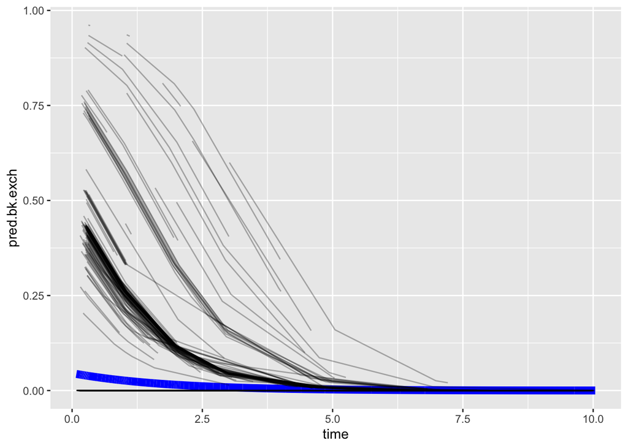

```r
  #Plots the predicted probabilities of BK from the
  #marginal model and the random intercept model
  ggplot(bk.Data, aes(x=time, y=pred.bk.exch)) +
    geom_line(colour="blue", lwd=3) +                    #marginal
    geom_line(aes(x=time, y=pred.bk.rInt, group=ID),     #random intercept
                alpha=.3)
```

Let’s plot the lines with “finer” time grid. The code is a bit more complicated because I am creating a new dataset for the predictions.

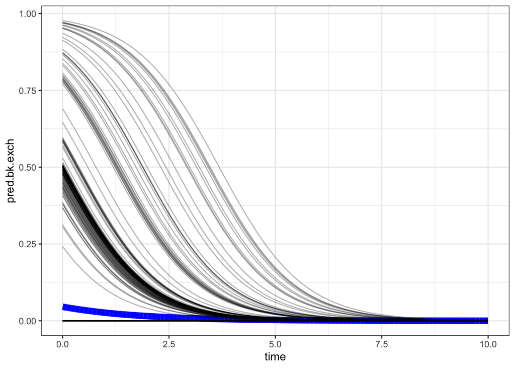

```r
newdata<-data.frame(ID=rep(unique(bk.Data$ID),each=101),
                    time=rep(seq(0,10,.1),length(unique(bk.Data$ID))))

newdata$pred.bk.rInt <- predict(rInt.bk,
                                type="response",
                                newdata=newdata)
newdata$pred.bk.exch <- predict(gee.bk.exch,
                                type="response",
                                newdata=newdata)

#Same thing as above
  ggplot(newdata, aes(x=time, y=pred.bk.exch)) +
    geom_line(colour="blue", lwd=3) +
    geom_line(aes(x=time, y=pred.bk.rInt, group=ID), alpha=0.3) +
    theme_bw()
```

**EXERCISE**: repeat the plot above but with the subject specific predictions based on the random intercept and random slope model

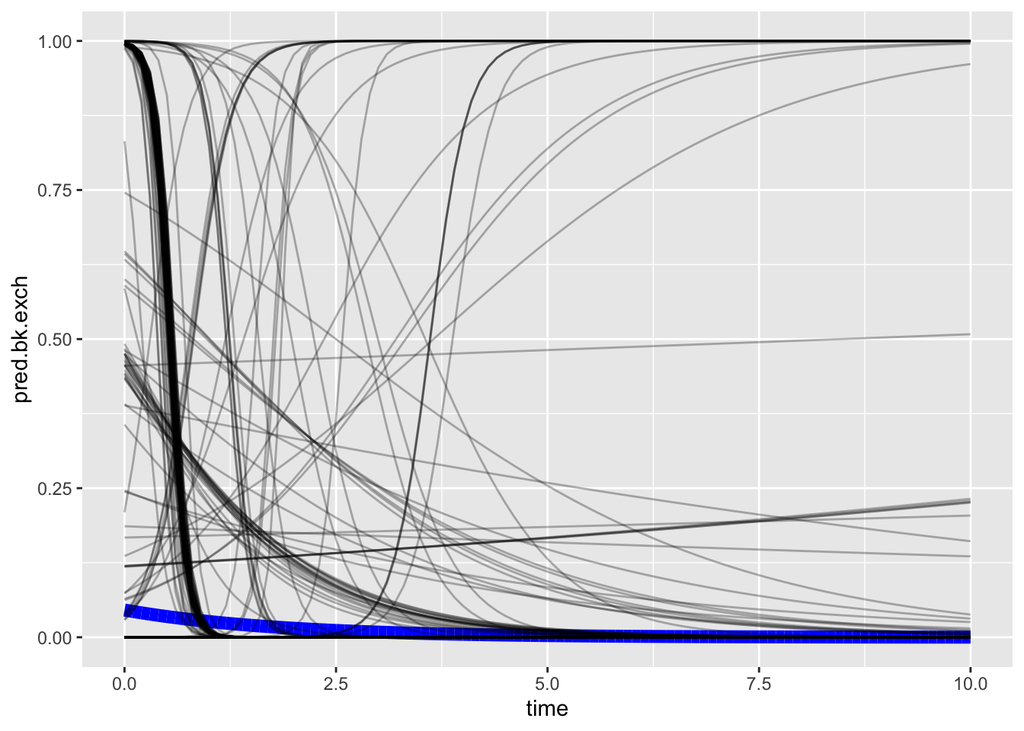

```r
newdata$pred.bk.rTime <- predict(rTime.bk,
                                 type="response",
                                 newdata=newdata)

ggplot(newdata, aes(x=time, y=pred.bk.exch)) +
  geom_line(colour="blue", lwd=3) +
  geom_line(aes(x=time,y=pred.bk.rTime, group=ID), alpha=0.3)
```

(slide 28) Fitting the marginal and random intercept models with the covariate sex

```r
gee.bk.exch2 <- geeglm(bk ~ time + gendercode,
                      family=binomial,
                      id=ID,
                      corst="exchangeable",
                      data=bk.Data)
summary(gee.bk.exch2)
```

```
Call:
geeglm(formula = bk ~ time + gendercode, family = binomial, data = bk.Data,
    id = ID, corstr = "exchangeable")

 Coefficients:
            Estimate Std.err   Wald Pr(>|W|)
(Intercept)  -3.3759  0.1857 330.53  < 2e-16 ***
time         -0.5638  0.0962  34.36  4.6e-09 ***
gendercodeM   0.4828  0.2122   5.18    0.023 *
---
Signif. codes:  0 '***' 0.001 '**' 0.01 '*' 0.05 '.' 0.1 ' ' 1

Correlation structure = exchangeable
Estimated Scale Parameters:

            Estimate Std.err
(Intercept)     1.03    1.93
  Link = identity

Estimated Correlation Parameters:
      Estimate Std.err
alpha    0.134   0.266
Number of clusters:   2009  Maximum cluster size: 13
```

```r
exp(gee.bk.exch2$coefficients)
```

```
(Intercept)        time gendercodeM
     0.0342      0.5690      1.6206
```

(slide 29) Fitting a logistic regression to BK status using a random intercept model

```r
rInt.bk2 <- glmer(bk ~ time + gendercode + (1|ID),   #random intercept
                 family=binomial,
                 data=bk.Data)

summary(rInt.bk2)
```

```
Generalized linear mixed model fit by maximum likelihood (Laplace
  Approximation) [glmerMod]
 Family: binomial  ( logit )
Formula: bk ~ time + gendercode + (1 | ID)
   Data: bk.Data

     AIC      BIC   logLik deviance df.resid
    1264     1292     -628     1256     8431

Scaled residuals:
   Min     1Q Median     3Q    Max
-3.278 -0.011 -0.008 -0.004 13.627

Random effects:
 Groups Name        Variance Std.Dev.
 ID     (Intercept) 60.7     7.79
Number of obs: 8435, groups:  ID, 2009

Fixed effects:
            Estimate Std. Error z value Pr(>|z|)
(Intercept)   -8.774      0.570  -15.39   <2e-16 ***
time          -1.022      0.124   -8.26   <2e-16 ***
gendercodeM    0.774      0.498    1.55     0.12
---
Signif. codes:  0 '***' 0.001 '**' 0.01 '*' 0.05 '.' 0.1 ' ' 1

Correlation of Fixed Effects:
            (Intr) time
time        -0.027
gendercodeM -0.728 -0.038
```

```r
exp(rInt.bk2@beta) #getting the odds ratio
```

```
[1] 0.000155 0.359772 2.168554
```

(slide 30) Plot

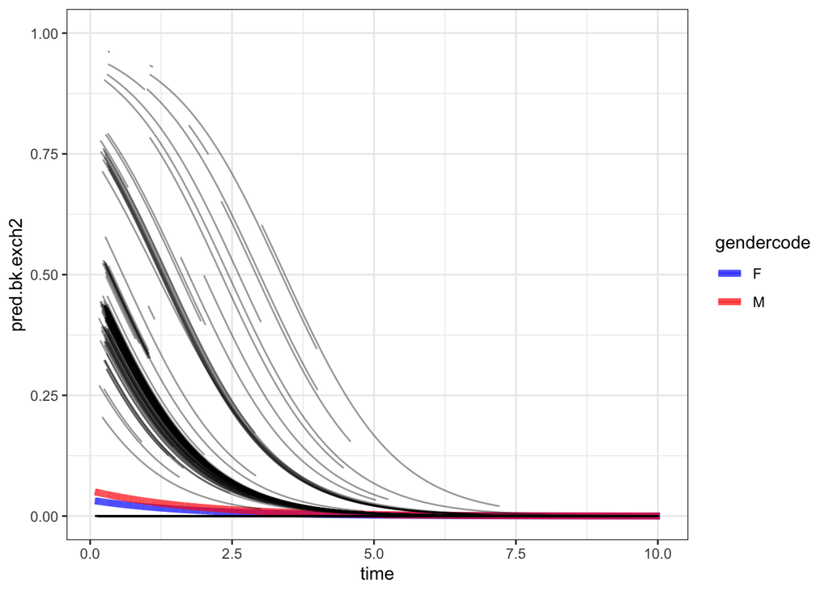

```r
pred.bk.exch2 <- predict(gee.bk.exch2, type="response")
pred.bk.rInt2 <- predict(rInt.bk2, type="response")

ggplot(bk.Data, aes(x=time, y=pred.bk.exch2, colour=gendercode)) +
  geom_line(lwd=2, lty=1,  alpha=.7) +                    #marginal
  scale_color_manual(values=c("blue", "red"))+
  geom_line(stat="smooth", method="glm",               #random intercept
            method.args = list(family = "binomial"),
            aes(x=time, y=pred.bk.rInt2, group=ID, coulor=gendercode),
            alpha=0.4) +
  theme_bw()
```

(slide 31) Fitting the marginal and random intercept models with the interaction between time and sex

```r
    gee.bk.exch3 <- geeglm(bk ~ time * gendercode,
                           family=binomial,
                           id=ID,
                           corst="exchangeable",
                           data=bk.Data)
    summary(gee.bk.exch3)
```

```
Call:
geeglm(formula = bk ~ time * gendercode, family = binomial, data = bk.Data,
    id = ID, corstr = "exchangeable")

 Coefficients:
                 Estimate Std.err   Wald Pr(>|W|)
(Intercept)        -3.483   0.225 239.33   <2e-16 ***
time               -0.446   0.166   7.24   0.0071 **
gendercodeM         0.641   0.271   5.61   0.0179 *
time:gendercodeM   -0.175   0.207   0.71   0.3982
---
Signif. codes:  0 '***' 0.001 '**' 0.01 '*' 0.05 '.' 0.1 ' ' 1

Correlation structure = exchangeable
Estimated Scale Parameters:

            Estimate Std.err
(Intercept)     1.02    1.78
  Link = identity

Estimated Correlation Parameters:
      Estimate Std.err
alpha    0.137   0.257
Number of clusters:   2009  Maximum cluster size: 13
```

```r
    exp(gee.bk.exch3$coefficients) #getting the odds ratio
```

```
     (Intercept)             time      gendercodeM time:gendercodeM
          0.0307           0.6399           1.8980           0.8393
```

(slide 33) Fitting a logistic regression to BK status using a random intercept model

```r
rInt.bk3 <- glmer(bk ~ time * gendercode + (1|ID),   #random intercept
                  family=binomial,
                  data=bk.Data)

summary(rInt.bk3)
```

```
Generalized linear mixed model fit by maximum likelihood (Laplace
  Approximation) [glmerMod]
 Family: binomial  ( logit )
Formula: bk ~ time * gendercode + (1 | ID)
   Data: bk.Data

     AIC      BIC   logLik deviance df.resid
    1262     1297     -626     1252     8430

Scaled residuals:
   Min     1Q Median     3Q    Max
-2.559 -0.011 -0.007 -0.004 19.404

Random effects:
 Groups Name        Variance Std.Dev.
 ID     (Intercept) 61.5     7.84
Number of obs: 8435, groups:  ID, 2009

Fixed effects:
                 Estimate Std. Error z value Pr(>|z|)
(Intercept)        -9.082      0.603  -15.07  < 2e-16 ***
time               -0.710      0.181   -3.93  8.5e-05 ***
gendercodeM         1.194      0.550    2.17    0.030 *
time:gendercodeM   -0.489      0.240   -2.03    0.042 *
---
Signif. codes:  0 '***' 0.001 '**' 0.01 '*' 0.05 '.' 0.1 ' ' 1

Correlation of Fixed Effects:
            (Intr) time   gndrcM
time        -0.239
gendercodeM -0.760  0.305
tim:gndrcdM  0.269 -0.739 -0.394
```

```r
exp(rInt.bk3@beta)   #getting the odds ratio
```

```
[1] 0.000114 0.491591 3.298830 0.613530
```

(slide 34) Plot

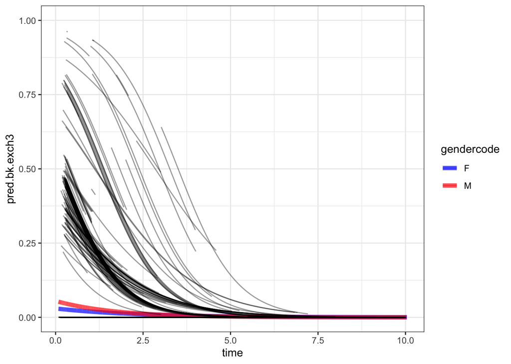

```r
pred.bk.exch3 <- predict(gee.bk.exch3, type="response")
pred.bk.rInt3 <- predict(rInt.bk3, type="response")

ggplot(bk.Data, aes(x=time, y=pred.bk.exch3, colour=gendercode)) +
  geom_line(lwd=2, lty=1,  alpha=.7) +                    #marginal
  scale_color_manual(values=c("blue", "red"))+
  geom_line(stat="smooth", method="glm",               #random intercept
            method.args = list(family = "binomial"),
            aes(x=time, y=pred.bk.rInt3, group=ID, coulor=gendercode), alpha=0.4) +
  theme_bw()
```

(slide 35) separate plot for men and women

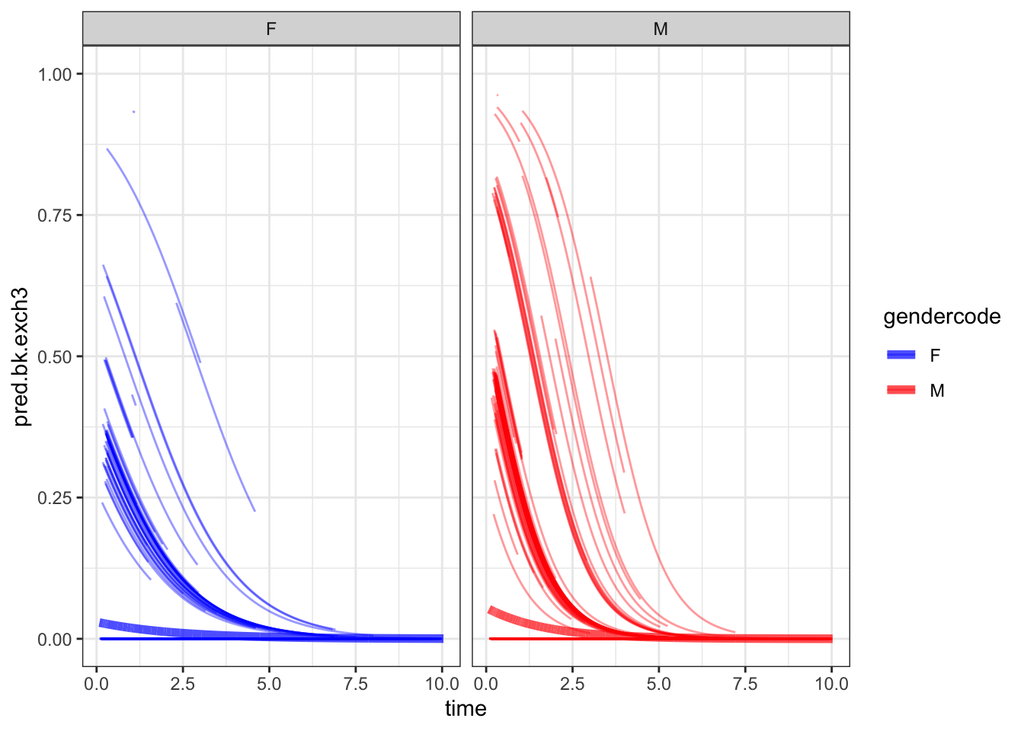

```r
ggplot(bk.Data, aes(x=time, y=pred.bk.exch3, colour=gendercode)) +
  geom_line(lwd=2, lty=1,  alpha=.7) +
  scale_color_manual(values=c("blue", "red"))+
  geom_line(stat="smooth", method="glm",
            method.args = list(family = "binomial"),
            aes(x=time, y=pred.bk.rInt3, group=ID, coulor=gendercode), alpha=0.4) +
  facet_grid(cols=vars(gendercode)) +
  theme_bw()
```

# Exercises

## Dataset

**Dataset**: afoot.csv

**Description**: results of a clinical trial to compare two competing oral antifungal treatments for athlete’s foot

**Variables**: - patient - a unique identifier for each patient in the trial.

- outcome - fungus present
- treatment - a factor with levels itraconazole (0) and terbinafine (1.
- month - in month when the visit actually took place.
- visit - number of visit attended.
- sexbin - male == 1

Read the dataset

```r
# Import afoot.csv dataset
afoot <- read.csv("https://www.dropbox.com/scl/fi/xgeu4z9cpml3ligdm8x62/afoot.csv?rlkey=ou3im1qfh498ohypw6557mom2&st=lbfer0vs&dl=1")
head(afoot)
```

Let’s lot the status over time of 40 patients

```r
ggplot(afoot[afoot$patient<40,],
       aes(x=month, y=as.factor(patient), colour=as.factor(outcome))) +
  geom_point() +
  geom_line(aes(group=patient), alpha=.8)  +
  facet_grid(col=vars(treatment)) +
  theme_bw()
```

## Questions

##### 1 - Considering that this is a trial, use a random intercept model to evaluate the effect of treatment. What would you report?

```r
rint.model <- glmer(outcome ~            ,
                    family=        ,
                    data=afoot)
summary(     )
#exp(confint(rint.model,method="Wald"))
exp(        )
```

```r
rint.model <- glmer(outcome~ month*treatment + (1|patient),
                    family=binomial,
                    data=afoot)
summary(rint.model)
#exp(confint(rint.model,method="Wald"))
exp(rint.model@beta)
```

##### 2 - Plot the predictions of the model in (#1)

```r
newdata<-data.frame(patient=rep(unique(afoot$patient),each=201),
                    treatment=rep(unique(afoot$treatment),each=201),
                    month=rep(seq(0,20,.1),length(unique(afoot$patient))))

newdata$rint.pred  <- predict(        )

ggplot(newdata, aes(x=       ,
                    y=       ,
                  group=       ,
                  colour=as.factor(       ))) +
  geom_line() +
  theme_bw()
```

```r
newdata<-data.frame(patient=rep(unique(afoot$patient),each=201),
                    treatment=rep(unique(afoot$treatment),each=201),
                    month=rep(seq(0,20,.1),length(unique(afoot$patient))))

newdata$rint.pred  <- predict(rint.model,
                              newdata=newdata,
                              type="response")

ggplot(newdata, aes(x=month,
                    y=rint.pred,
                  group=patient,
                  colour=as.factor(treatment))) +
  geom_line() +
  theme_bw()
```

##### 3 - Compare a random intercept and random slope for month with the model in (#1)

```r
rslp.model <- glmer(outcome~treatment*month + (        ),
                    family=binomial,
                    data=afoot)

summary(          )

exp(            )

anova()
```

```r
rslp.model <- glmer(outcome~treatment*month + (1+month|patient),
                    family=binomial,
                    data=afoot)
summary(rslp.model)
#exp(confint(rslp.model,method="Wald"))
exp(rslp.model@beta)

anova(rint.model, rslp.model)
```

##### 4 - Analyse the same question as (#1) but using a GEE with exchangeable correlation and with independence correlation structure. Which one would you choose for your final analysis

```r
    # GEE with exchangeable correlation
    gee.model1 <- geeglm(                ,
                         data =  ,
                         id =             ,
                         corstr = "        ",
                         family =             )
    summary(gee.model1)

    # GEE with independent correlation
    gee.model2 <- geeglm(            ,
                         data =      ,
                         id =            ,
                         corstr = "        ",
                         family =        )
    summary(gee.model2)

    #compare both GEEs
    QIC(            )
```

```r
    # GEE with exchangeable correlation
    gee.model1 <- geeglm(outcome ~ treatment*month,
                         data = afoot,
                         id = patient,
                         corstr = "exchangeable",
                         family = binomial)
    summary(gee.model1)

    # GEE with independent correlation
    gee.model2 <- geeglm(outcome ~ treatment*month,
                         data = afoot,
                         id = patient,
                         corstr = "independence",
                         family = binomial)
    summary(gee.model2)

    #compare both GEEs
    QIC(gee.model1, gee.model2)
```